# Hierarchical model with JAGS

Sami Cheong

3/23/2021

## Part A: JAGS Basics

### A1. Data Assembly and Building Model Object

```r
## 1. Data Assembly
## Suppose in this case we have a series of coin flips. We can use rbinom to simulate that:

y <-  rbinom(1,10,0.1)

## create the list object:

Ntotal = length(y)  # Compute the total number of flips.
dataList = list(    # Put the information into a list.
  y=y,
  Ntotal = Ntotal
)
```

```r
## defining model string

modelString <-"
model {
  for ( i in 1:Ntotal){
   y[i] ~ dbern( theta )

  }

  theta ~ dbeta( 1, 1 )

}

"
writeLines( modelString , con="TEMPmodel.txt" ) # write to file
```

### A2. Set up initial value for theta

```r
# set up initial value for theta
thetaInit = sum(y)/length(y)
# put initial theta in a list object
initsList = list( theta=thetaInit )

## Define jagsModel
jagsModel = jags.model( file="TEMPmodel.txt" , data=dataList , inits=initsList ,
                        n.chains=3 , n.adapt=500 )
## Alternatively, we can generate a random value for the initial list using the following function:

initsList = function(y) {
  resampledY = sample( y , replace=TRUE )        # resample values from y
  thetaInit = sum(resampledY)/length(resampledY) # compute proportion (MLE)
  thetaInit = 0.001+0.998*thetaInit              # keep away from 0,1
  return( list( theta=thetaInit ) )              # return as a named list
}
```

### A3. Generating Markov Chains

```r
jagsModel2 = jags.model( file="TEMPmodel.txt" , data=dataList , inits=initsList(dataList$y) ,
                        n.chains=3 , n.adapt=500 )
## 2. Generating a Markov chain: After JAGS has created its model, we tell it to run the chains some number of steps to accomplish burn in.
## recompile model:
update(object = jagsModel2,n.iter = 500)

# in case of error for recompile, use this: jagsModel2$recompile()

codaSamples = rjags::coda.samples( model = jagsModel2 , variable.names=c("theta") ,
                            n.iter=2000 )
```

### A4. Analyzing Markov Chains through Visualizations

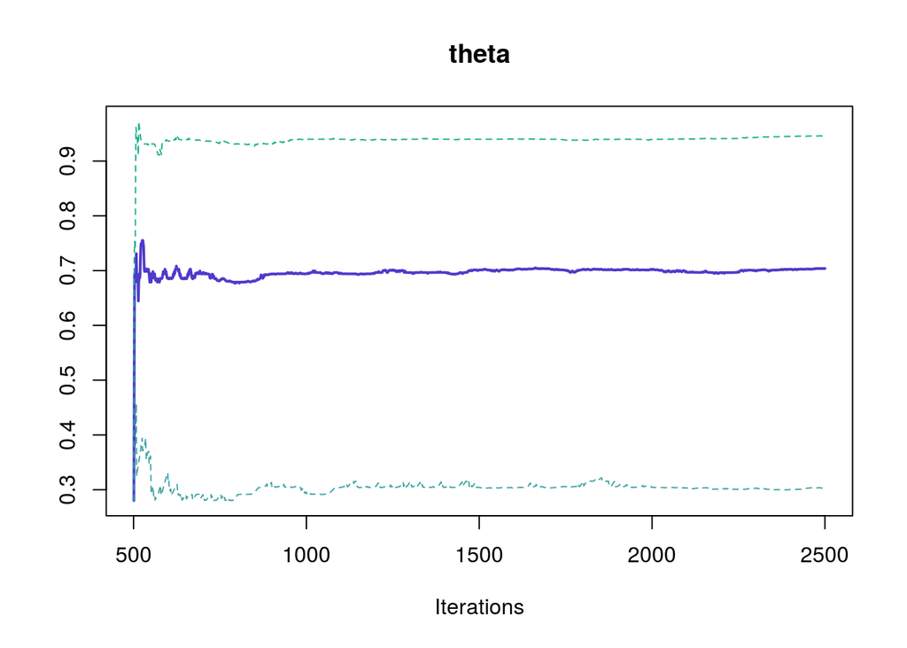

```r
### 3. Visualizing the Markov chain


### try out some coda function

### set color vec:

color_vec <- c('#43A5A4','#4E3ACB','#1BAF8B','#2E5458','#2FC44F','#10595D','#0DCADD')

### cumulative quantle plot


coda::cumuplot(codaSamples[[1]],col = color_vec,probs = c(0.1,0.5,0.9))
```

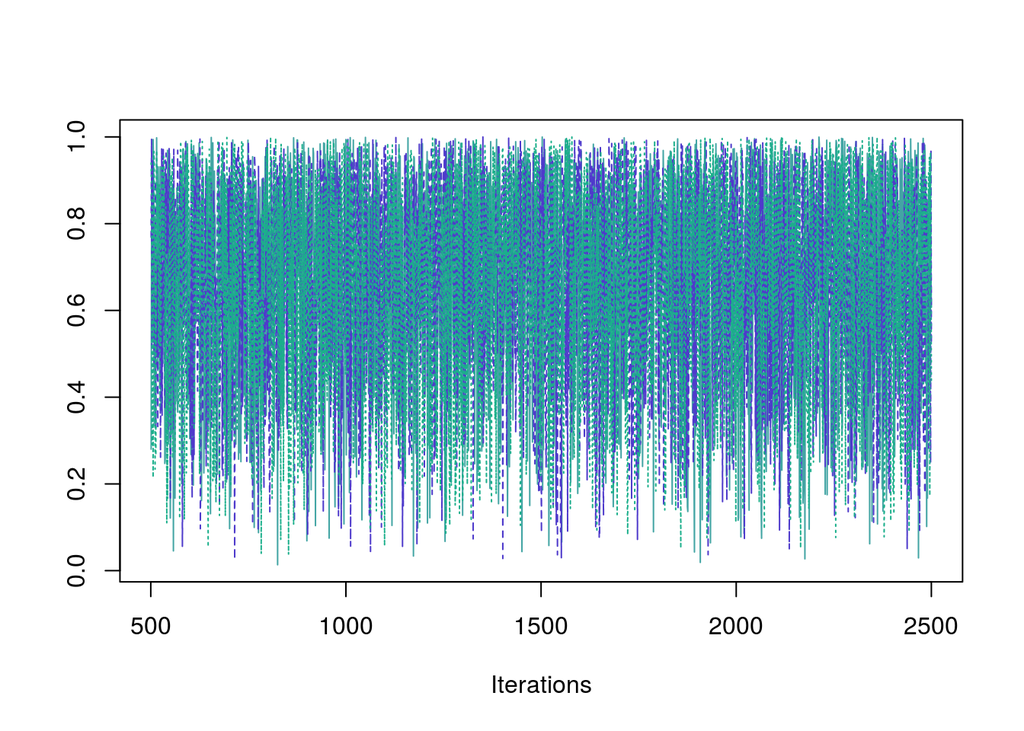

```r
### traceplot:

traceplot(codaSamples[,'theta'],col = color_vec)
```

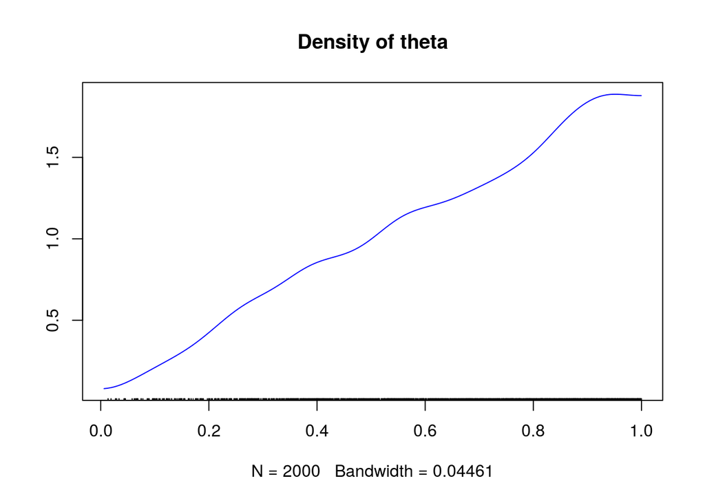

```r
### densty plot:

coda::densplot(codaSamples,col='blue')
```

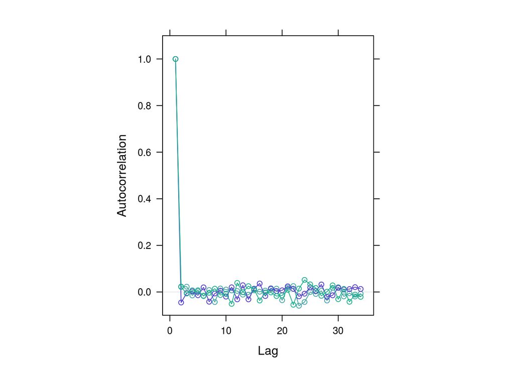

```r
### auto-correlation function plot: shows serial correlation of theta over time

coda::acfplot(codaSamples,col=color_vec,ylim=c(-0.1,1.1))
```

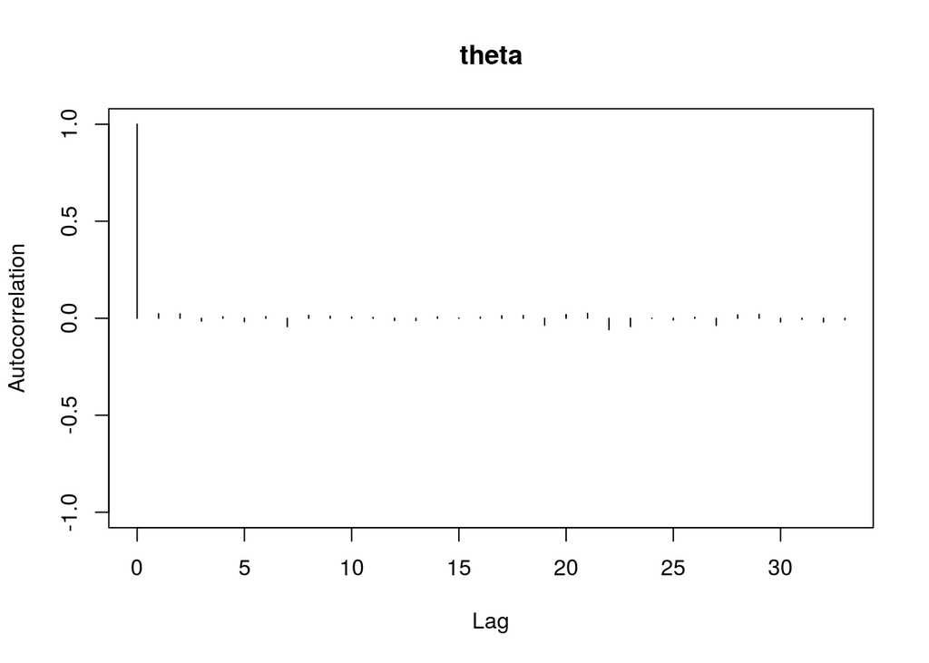

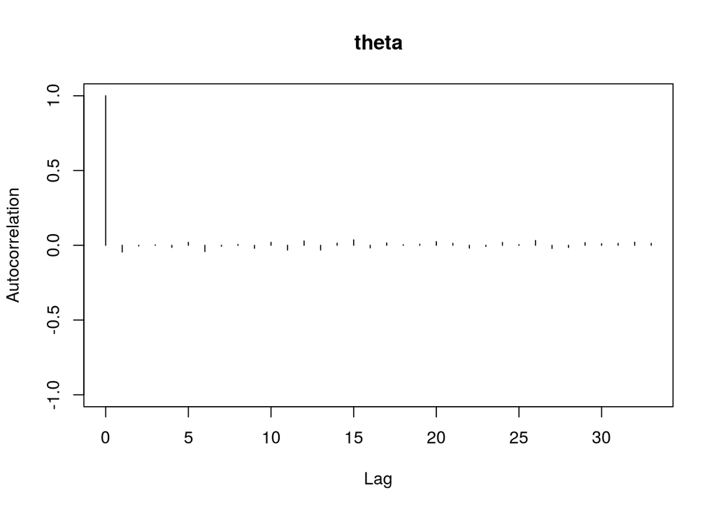

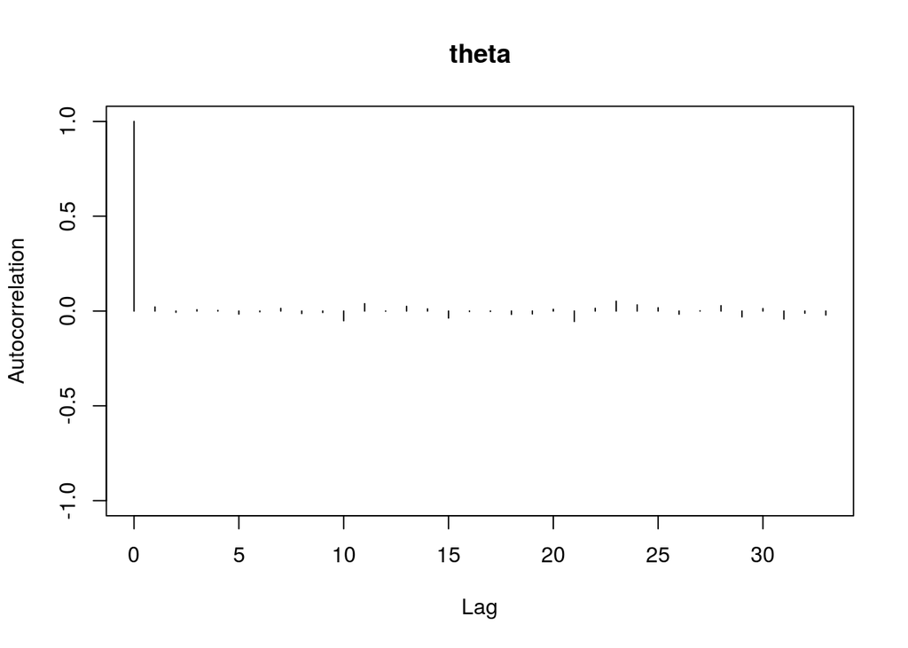

```r
coda::autocorr.plot(codaSamples)
```

## Part B: Modeling Example with Real Data

From the text book: "_Therapeutic touch is a nursing technique in which the practitioner manually manipulates the “energy field” of a patient who is suffering from a disease. The practitioner holds her or his hands near but not actually touching the patient, and repatterns the energy field to relieve congestion and restore balance, allowing the body to heal. Rosa, Rosa, Sarner, and Barrett (1998) reported that therapeutic touch has been widely taught and widely used in nursing colleges and hospitals despite there being little if any evidence of its efficacy."

Claim:

- practitioners can sense a body’s energy field.

Experiment:

- The practitioner sat with her hands extended through cutouts in a cardboard screen, which prevented the practitioner from seeing the experimenter. On each trial, the experimenter flipped a coin and held her hand a few centimeters above one or the other of the practitioner’s hands, as dictated by the flip of the coin.
- The practitioner then responded with her best guess regarding which of her hand’s was being hovered over. Each trial was scored as correct or wrong. The experimenter (and co-author of the article) was 9-years old at the time.

https://www.physics.smu.edu/pseudo/AlternativeMedicine/Rosa.pdf

## B.1 Read in the data:

```r
# Read the data file:
data = read.csv("TherapeuticTouchData.csv")
# Load the relevant model functions into R’s working memory:

# y = observed responses
y = data[,"y"]
# s = groups
s = as.numeric(factor(data[,"s"]))

# set data and group size:
Ntotal = length(y)
Nsubj = length(unique(s))
```

### B.2. Assemble data list:

```r
# set data list :

dataList = list(
    y = y ,
    s = s ,
    Ntotal = Ntotal ,
    Nsubj = Nsubj
  )
```

### B.3 Define model

```r
# create hierarchcial model:

modelString = "
  model {
    for ( i in 1:Ntotal ) {
    # top level: y is a Bernoulli random varable
      y[i] ~ dbern( theta[s[i]] )
    }
    for ( sIdx in 1:Nsubj ) {
    # for each group, designate a different theta with beta distribution
      theta[sIdx] ~ dbeta( omega*(kappa-2)+1 , (1-omega)*(kappa-2)+1 )
    }
    # parameter for the beta distribution
    omega ~ dbeta( 1 , 1 ) # broad uniform
    # omega ~ dbeta( 5001 , 15001 ) # Skeptical prior for ESP
    # more hierarchy for kappa
    kappa <- kappaMinusTwo + 2
    # kappaMinusTwo ~ dgamma( 0.01 , 0.01 )  # mean=1 , sd=10 (generic vague)
    kappaMinusTwo ~ dgamma( 1.105125 , 0.1051249 )  # mode=1 , sd=10
    # kappaMinusTwo ~ dgamma( 36 , 0.12 )  # mode=300 , sd=50 : skeptical
  }"

writeLines( modelString , con="TEMPmodel_BHM.txt" )
```

## B.4 Initial values of MCMC chains based on data:

```r
### initial theta (a list of 28 - 1 theta for each group)
thetaInit = rep(0,Nsubj)
for ( sIdx in 1:Nsubj ) { # for each subject

  includeRows = ( s == sIdx ) # identify rows of this subject

  yThisSubj = y[includeRows]  # extract data of this subject

  resampledY = sample( yThisSubj , replace=TRUE ) # resample

  thetaInit[sIdx] = sum(resampledY)/length(resampledY)
}

# ensure there are no values that are exactly 0 for computational purposes:

thetaInit = 0.001+0.998*thetaInit

### initial omega:

omegaInit <-  mean(thetaInit)


### initial kappaMinusTwo - set some random value and see what happens

kappaMinusTwoInit <- 100

initsList <-list(theta = thetaInit,  omega= omegaInit, kappaMinusTwo = kappaMinusTwoInit)
```

### B.5 Initialize parameters and build the chainn

```r
parameters = c( "theta","omega","kappa") # The parameters to be monitored
adaptSteps = 500             # Number of steps to adapt the samplers
burnInSteps = 500            # Number of steps to burn-in the chains
nChains = 4       # nChains should be 2 or more for diagnostics
numSavedSteps = 50000  # Number of steps to save in the MC
thinSteps = 1
nIter = ceiling( ( numSavedSteps * thinSteps ) / nChains )
# Create, initialize, and adapt the model:
jagsModel = jags.model( "TEMPmodel_BHM.txt" , data=dataList , inits=initsList ,
                        n.chains=nChains , n.adapt=adaptSteps )
# Burn-in:
cat( "Burning in the MCMC chain...\n" )
```

```
## Burning in the MCMC chain...
```

```r
update( jagsModel , n.iter=burnInSteps )
# The saved MCMC chain:
cat( "Sampling final MCMC chain...\n" )
```

```
## Sampling final MCMC chain...
```

```r
codaSamples = rjags::coda.samples( jagsModel , variable.names=parameters ,
                            n.iter=nIter , thin=thinSteps )

#View(smryMCMC(codaSamples))
```

### B.3. Visualizing results:

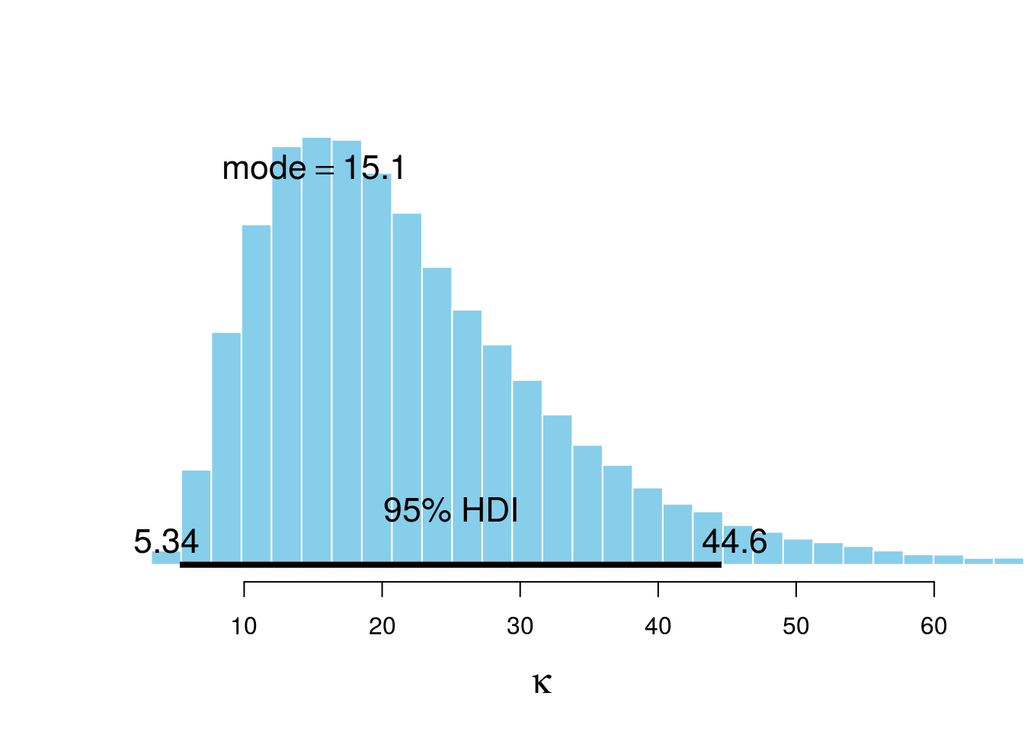

```r
mcmcMat <- as.matrix(codaSamples,chains = TRUE)
postKappa <-   plotPost( mcmcMat[,"kappa"] , compVal=NULL , ROPE=NULL ,
                       xlab=bquote(kappa) , main="" ,
                       xlim=c( min(mcmcMat[,"kappa"]),
                               quantile(mcmcMat[,"kappa"],probs=c(0.990)) ) )
```

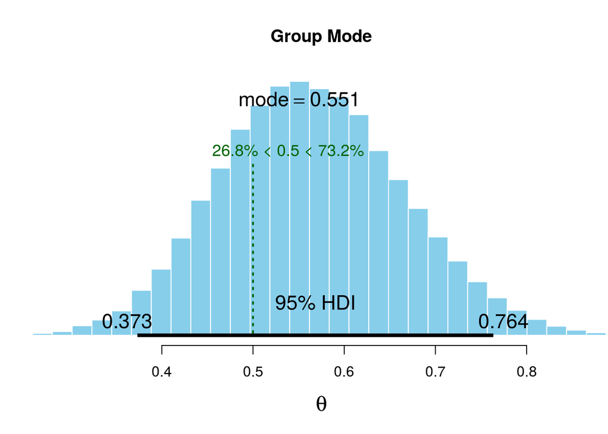

```r
postOmega <- plotPost( mcmcMat[,"theta[28]"] , compVal=0.5 , ROPE=NULL ,
                       xlab=bquote(theta) , main="Group Mode" ,
                       xlim=quantile(mcmcMat[,"theta[28]"],probs=c(0.005,0.995)) )
```